# hw_3

Ответ Ответович Ответов

```r
library(tidyverse)
theme_set(theme_bw())
knitr::opts_chunk$set(message = FALSE)
library(fitdistrplus)
library(lme4)
library(lmerTest)
```

## task 3.1 (вес задания: 3)

В датасет `vowel_data.csv` записаны значения формант гласных для носителей британского английского языка из исследования [Sönning, Lukas 2021]. Используя данные всех носителей, проведите эмпирическую байесовскую оценку, чтобы получить априорное распределение, сделайте байесовский апдейт всех носителей и постройте график 80% доверительных интервалов для каждого носителя. Какой носитель, согласно полученным доверительным интервалам, показывает самую невыразительную разницу между гласными?

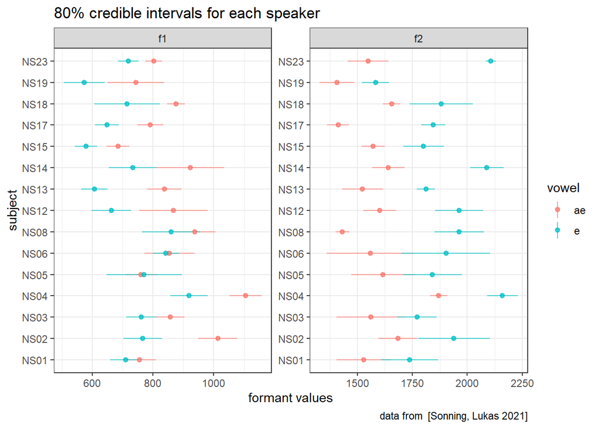

[figure not shown]

```r
br_vowels <- read_csv("vowel_data.csv")


e_f1 <- fitdist(filter(br_vowels, vowel == 'e')$F1, distr = 'norm', method = 'mle')
e_f2 <- fitdist(filter(br_vowels, vowel == 'e')$F2, distr = 'norm', method = 'mle')
ae_f1 <- fitdist(filter(br_vowels, vowel == 'ae')$F1, distr = 'norm', method = 'mle')
ae_f2 <- fitdist(filter(br_vowels, vowel == 'ae')$F2, distr = 'norm', method = 'mle')

e_f1$estimate %>%
  bind_rows(e_f2$estimate,
            ae_f1$estimate,
            ae_f2$estimate) %>%
  mutate(formant = c("f1", "f2", "f1", "f2"),
         vowel = c("e", "e", "ae", "ae")) %>%
  rename(mean_prior = mean,
         sd_prior = sd) ->
  priors

br_vowels %>%
  group_by(subject, vowel) %>%
  summarise(mean_f1 = mean(F1),
            mean_f2 = mean(F2),
            sd_f1 = sd(F1),
            sd_f2 = sd(F2)) %>%
  pivot_longer(names_to = "type", values_to = "values", mean_f1:sd_f2) %>%
  separate(type, into = c("type", "formant")) %>%
  pivot_wider(values_from = values, names_from = "type") %>%
  left_join(priors) %>%
  rowwise() %>%
  mutate(sd_post = 1/sqrt(1/sd_prior^2 + 1/sd^2),
         mean_post = weighted.mean(c(mean_prior, mean),
                                   c(1/sd_prior^2, 1/sd^2)),
         cred_int_l_80 = qnorm(0.1, mean_post, sd_post),
         cred_int_h_80 = qnorm(0.9, mean_post, sd_post),
         cred_int_mean = cred_int_h_80-(cred_int_h_80-cred_int_l_80)/2) %>%
  ggplot(aes(y = subject, x = cred_int_mean,
             xmin = cred_int_l_80, xmax = cred_int_h_80, color = vowel))+
  geom_pointrange(alpha = 0.7, shape = 20)+ # это не обязательные параметры
  facet_wrap(~formant, scales = "free")+
  labs(x = "formant values",
       title = "80% credible intervals for each speaker",
       caption  = "data from  [Sönning, Lukas 2021]")
```

Ответ: NS05

## task 3.2 (вес задания: 3)

В датасет `norwegian_lexical_development.csv` записаны данные из исследования [Hansen 2017], посвященного усваиванию лексики носителями норвежского. В датасете собраны следующие переменные:

- `Word_NW` – норвежские слова;
- `Translation` – перевод норвежских слов на английский;
- `CDS_freq` – усредненная частота слова в речи, адресованной детям;
- `AoA` – усредненный возраст освоения слова (в месяцах);
- `Lex_cat` – лексическая категория, приписанная исследователями.

Постройте и визуализируйте лучшую регрессию, которая предсказывает возраст усвоения слова в зависимости от частотности в речи, адресованной детям. Помните про необходимость преобразования переменных, чтобы связь была линейной. Сравните полученный результат с результатом работы функции `geom_smooth()`, которая генерирует отдельную независимую регрессию для каждой из групп.

```r
nld <- read_csv("norwegian_lexical_development.csv")


fit1 <- lmer(AoA~log(CDS_freq)+(1|Lex_cat), data = nld)
fit2 <- lmer(AoA~log(CDS_freq)+(1+log(CDS_freq)|Lex_cat), data = nld)

anova(fit1, fit2) # fit2 is better
```

```
## Data: nld
## Models:
## fit1: AoA ~ log(CDS_freq) + (1 | Lex_cat)
## fit2: AoA ~ log(CDS_freq) + (1 + log(CDS_freq) | Lex_cat)
##      npar    AIC    BIC  logLik deviance  Chisq Df Pr(>Chisq)
## fit1    4 3026.3 3043.7 -1509.2   3018.3
## fit2    6 3007.8 3033.9 -1497.9   2995.8 22.507  2  1.296e-05 ***
## ---
## Signif. codes:  0 '***' 0.001 '**' 0.01 '*' 0.05 '.' 0.1 ' ' 1
```

[figure not shown]

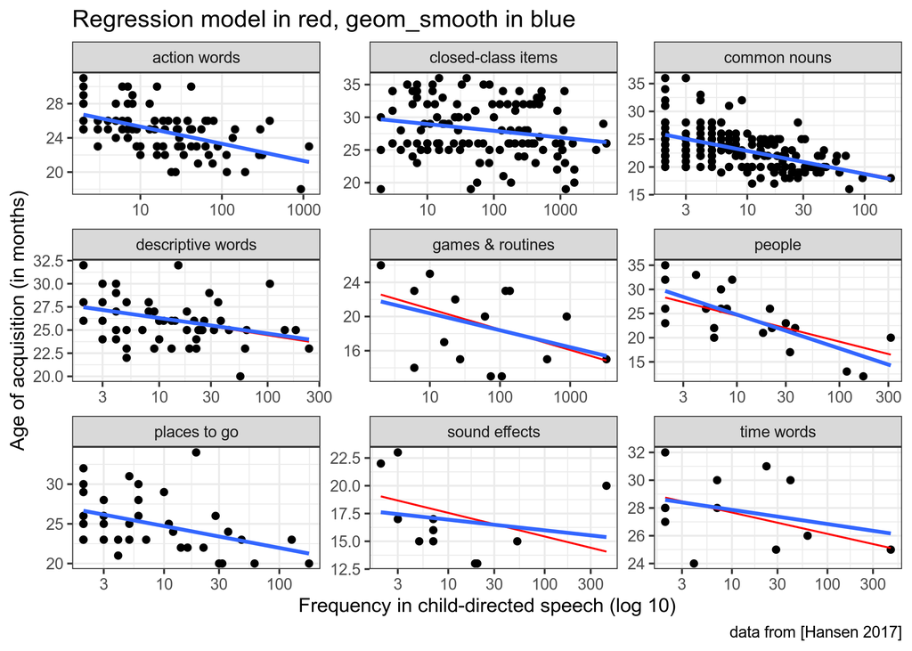

```r
nld %>%
  mutate(predicted = predict(fit2)) %>%
  ggplot(aes(CDS_freq, AoA))+
  geom_point()+
  geom_line(aes(y = predicted), color = "red", alpha = 0.7)+
  scale_x_log10()+
  geom_smooth(method = "lm", se = FALSE, alpha = 0.6, size = 0.5)+
  facet_wrap(~Lex_cat, scales = "free")+
  labs(x = "Frequency in child-directed speech (log 10)",
       y = "Age of acquisition (in months)",
       title = "Regression model in red, geom_smooth in blue",
       caption = "data from [Hansen 2017]")
```

## task 3.3 (вес задания: 2)

Перед вами четыре графика остатков. Проанализируйте каждый из них и опишите нарушения ограничений на применение регрессии, которые вы можете увидеть.

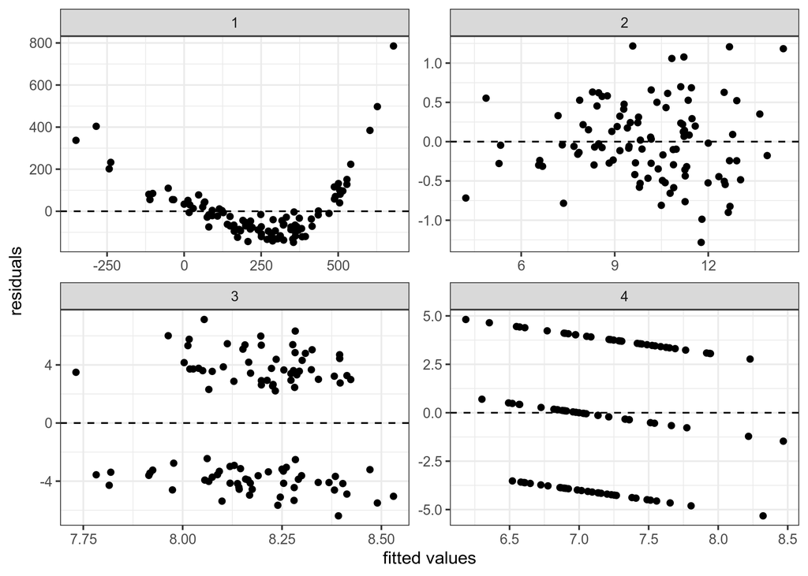

### График 1

Явная нелинейная зависимость.

### График 2

Остатки распределены гетероскедастично: с увеличением значения дисперсия увличивается.

### График 3

Выделяются две группы, на линии нуля остатков вообще нет.

### График 4

Остатки образуют четкий паттерн.

## task 3.4 (вес задания: 1)

Место для рефлексии по поводу ответов. Заполняется после того, как присланы ответы на задания до 28.03.2021 23:59. Это оцениваемое задание.